# Untitled

2023-03-13

```r
# Data wrangling packages
library(tibble)
library(tidyr)
library(dplyr)
library(purrr)

# MALDI packages
library(MALDIquant)
library(MALDIquantForeign)

# ML packages
library(umap)
library(glmnet)

# Visualization packages
library(ggplot2)
library(cowplot)
library(ggrepel)

# Project package
library(ink)
```

### Peak calling of validation data and training data

```r
#, cache = TRUE}
# The two included datasets (msdata in maldiquant)
data(training_data)
data(validation_data)

# Concatenate data to one list
msdata <- c(training_data, validation_data)

# Preprocess data
Methods        <- c("SavitzkyGolay", "MovingAverage")
spectra        <- transformIntensity(msdata, method="log2")
spectra        <- smoothIntensity(spectra, method=Methods[1],halfWindowSize=4)
spectra        <- removeBaseline(spectra, method="SNIP", iterations=100) #100
spectra        <- alignSpectra(spectra, halfWindowSize = 20, SNR = 4)
peaks_full     <- detectPeaks(spectra, SNR=3, halfWindowSize=20) # 15
peaks_full     <- binPeaks(peaks_full, tolerance=60*1e-6) #150
peaks_full     <- filterPeaks(peaks_full, minFrequency=0.01)
featureMatrix  <- intensityMatrix(peaks_full, spectra)
intensity_data <- as_tibble(featureMatrix)

# Set colnames of feature tibble
colnames(intensity_data) <- paste0("M", round(as.numeric(colnames(intensity_data)), 4))
head(intensity_data)
```

```
## # A tibble: 6 × 9,761
##   M100.0978 M100.1042 M100.1086 M100.1…¹ M100.…² M101.…³ M101.…⁴ M102.…⁵ M102.…⁶
##       <dbl>     <dbl>     <dbl>    <dbl>   <dbl>   <dbl>   <dbl>   <dbl>   <dbl>
## 1      2.26      1.50      1.69     1.66    1.65   2.39    2.36     1.50    4.98
## 2      2.35      2.20      2.11     1.57    1.88   1.73    1.72     1.88    3.92
## 3      2.39      2.26      2.25     2.23    2.22   1.78    1.86     1.95    1.49
## 4      2.42      2.15      1.90     1.75    1.74   0.669   0.546    1.94    2.07
## 5      3.45      2.91      2.68     2.27    1.97   1.09    2.48     1.72    1.61
## 6      1.02      1.09      1.14     1.51    2.12   1.66    1.41     2.29    4.72
## # … with 9,752 more variables: M104.1195 <dbl>, M104.1263 <dbl>,
## #   M104.1327 <dbl>, M104.1392 <dbl>, M104.1422 <dbl>, M105.0579 <dbl>,
## #   M105.064 <dbl>, M105.0702 <dbl>, M105.096 <dbl>, M106.1034 <dbl>,
## #   M106.1107 <dbl>, M106.1181 <dbl>, M107.0643 <dbl>, M107.0734 <dbl>,
## #   M107.0807 <dbl>, M107.1027 <dbl>, M107.1103 <dbl>, M107.1134 <dbl>,
## #   M107.1162 <dbl>, M107.1211 <dbl>, M109.0958 <dbl>, M109.117 <dbl>,
## #   M109.1256 <dbl>, M110.0891 <dbl>, M110.1068 <dbl>, M110.1167 <dbl>, …
```

### Parse metadata retained in msdata filenames

```r
inkdata <-
  tibble(
    pen   = gsub(".*pen|_.*", "", names(msdata)),
    index = gsub(".*index|_rep.*", "", names(msdata)),
    rep   = gsub(".*_rep|.mzML", "", names(msdata))
  ) |>
  mutate(
    age = 44-case_when(
      index == 0~0,
      index == 1~3,
      index == 2~7,
      index == 3~9,
      index == 4~13,
      index == 5~17,
      index == 6~20,
      index == 7~24,
      index == 8~28,
      index == 9~31,
      index == 10~35,
      index == 11~38,
      index == 12~41,
      index == 13~44
    ),
    type = case_when(grepl("blank", pen)~"blank",grepl("sign", pen)~"validation", !grepl("blank", pen)~"sample")
  ) |>
  bind_cols(intensity_data)

head(inkdata)
```

```
## # A tibble: 6 × 9,766
##   pen   index rep     age type   M100.…¹ M100.…² M100.…³ M100.…⁴ M100.…⁵ M101.…⁶
##   <chr> <chr> <chr> <dbl> <chr>    <dbl>   <dbl>   <dbl>   <dbl>   <dbl>   <dbl>
## 1 1     0     1        44 sample    2.26    1.50    1.69    1.66    1.65   2.39
## 2 1     0     2        44 sample    2.35    2.20    2.11    1.57    1.88   1.73
## 3 1     0     3        44 sample    2.39    2.26    2.25    2.23    2.22   1.78
## 4 1     1     1        41 sample    2.42    2.15    1.90    1.75    1.74   0.669
## 5 1     1     2        41 sample    3.45    2.91    2.68    2.27    1.97   1.09
## 6 1     1     3        41 sample    1.02    1.09    1.14    1.51    2.12   1.66
## # … with 9,755 more variables: M101.0957 <dbl>, M102.0789 <dbl>,
## #   M102.1139 <dbl>, M104.1195 <dbl>, M104.1263 <dbl>, M104.1327 <dbl>,
## #   M104.1392 <dbl>, M104.1422 <dbl>, M105.0579 <dbl>, M105.064 <dbl>,
## #   M105.0702 <dbl>, M105.096 <dbl>, M106.1034 <dbl>, M106.1107 <dbl>,
## #   M106.1181 <dbl>, M107.0643 <dbl>, M107.0734 <dbl>, M107.0807 <dbl>,
## #   M107.1027 <dbl>, M107.1103 <dbl>, M107.1134 <dbl>, M107.1162 <dbl>,
## #   M107.1211 <dbl>, M109.0958 <dbl>, M109.117 <dbl>, M109.1256 <dbl>, …
```

### Visualize the raw data before normalizing it

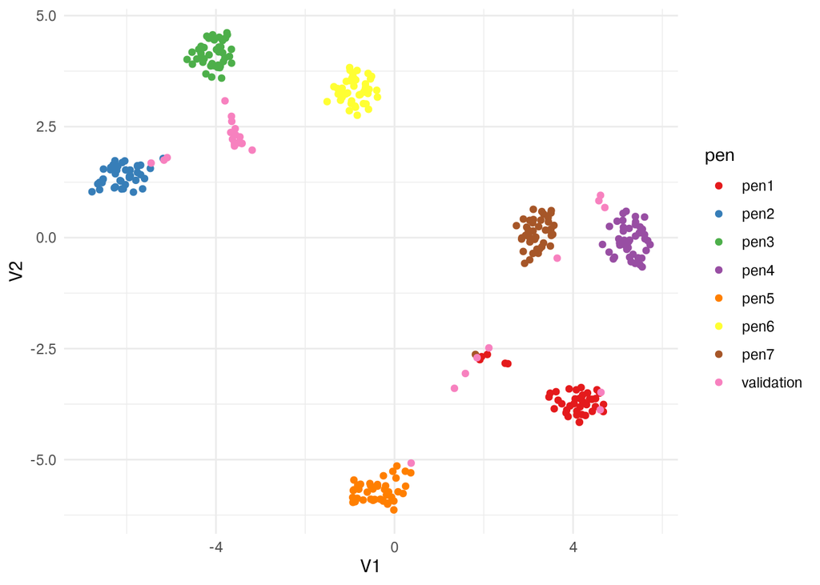

```r
pen   <- paste0("pen", inkdata |> filter(type %in% c("sample", "validation")) |> pull(pen))
age   <- inkdata |> filter(type %in% c("sample", "validation")) |> pull(age)
x     <- inkdata |> filter(type %in% c("sample", "validation")) |> select(starts_with("M"))

um <- umap(x)
um$layout |>
  as_tibble() |>
  mutate(pen = case_when(pen %in% paste0("pen", 1:7)~pen, !pen %in% paste0("pen", 1:7) ~ "validation")) |>
  ggplot(aes(x=V1, y=V2, color = pen))+
  geom_point()+
  scale_color_brewer(palette = "Set1")+
  theme_minimal()
```

```r
# container to ease preprocessing
ms <- list()
ms$values  <- inkdata |> select(starts_with("M"))
ms$rowinfo <- inkdata |> select(-starts_with("M")) |> rowid_to_column()


# Remove features with intensities less than 1.5 times the median of the blank intensity
feature_in_blank <-
  ms$rowinfo |>
  bind_cols(ms$values) |>
  pivot_longer(cols = starts_with("M")) |>
  group_by(name, type) |>
  summarise(median_variance = mad(value)) |>
  pivot_wider(names_from = type, values_from = median_variance) |>
  mutate(good_feature = sample > (blank*1.5))

good_features <- feature_in_blank |> filter(good_feature) |> pull(name)
ms$values     <- ms$values[,good_features]
ms            <- ms |> transform_log() |> normalize_robust_row()
inkdata2      <- ms |> bind_cols()
```

# Visualize the spectra of the average sample

Plotting the pooled spectra from the experiment across all time points

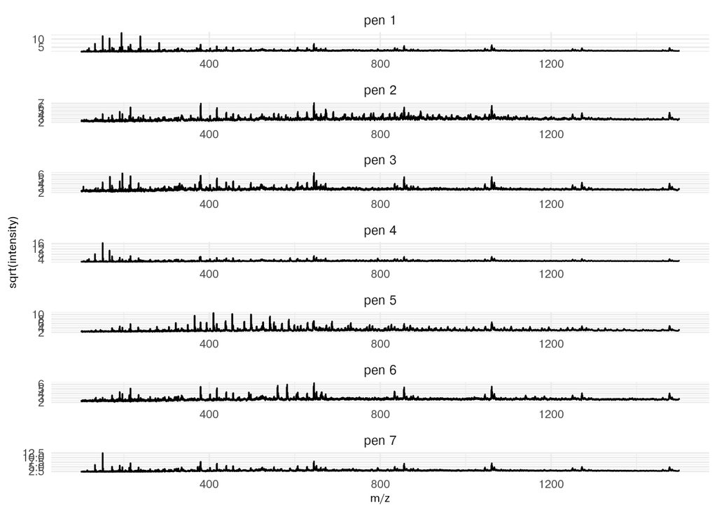

```r
# Extract mass and intensity from the raw data
df <-
  msdata |>
  map(~tibble(mass = mass(.x), intensity = intensity(.x))) |>
  bind_rows(.id = "file") |>
  mutate(pen = gsub(".*pen|_index.*", "", file))

# Pool scans (m/z - intensity pairs) into bins of 5 to reduce computations. The bins are summarised by mean values of intensity.
df2 <-
  df |>
  filter(pen %in% 1:7) |>
  group_by(pen, mass) |>
  summarise(intensity = mean(intensity)) |>
  group_by(pen) |>
  mutate(rowid = (row_number() %/% 5)) |>
  group_by(rowid, pen) |>
  summarise(intensity = mean(intensity), mass = mean(mass))

# Visualize the spectra
(spectra_plots <-
  df2 |>
  group_by(pen) |>
  mutate(intensity = zoo::rollmean(intensity, 20, fill = NA, align = 'right')) |>
    mutate(pen = paste("pen", pen)) |>
  ggplot(aes(x=mass, y=intensity^0.5))+
  geom_line()+
  facet_wrap(~pen, scales = "free", ncol = 1)+
  theme_minimal()+
    labs(x = "m/z", y="sqrt(intensity)")+
    theme(axis.text = element_text(size=8), axis.title = element_text(size=8))
)
```

## Visualize unsupervised machine learning

First we’ll assign feature values to x, time points to age, and pen brand to pen.

```r
pen       <- paste0("pen", inkdata2 |> filter(type == "sample") |> pull(pen))
age       <- inkdata2 |> filter(type == "sample") |> pull(age)
x         <- inkdata2 |> filter(type == "sample") |> select(starts_with("M"))
```

### Umap

```r
um <- umap::umap(x)

umap_plot <-
    um$layout |>
    as_tibble() |>
    mutate(pen = pen) |>
    ggplot(aes(x=V1, y=V2, fill = pen))+
    geom_point(color = "white", shape=21)+
    scale_fill_brewer(palette = "Set1")+
    theme_minimal()+
    labs(x = "umap1", y="umap2", title = "umap")+
    theme(
      axis.text = element_text(size=8),
      axis.title = element_text(size=8),
      plot.title = element_text(size=8),
      legend.text = element_text(size=8),
      legend.title = element_text(size=8)
    )
```

### PCA

```r
pca <- prcomp(x)
variance_explained <- summary(pca)$importance[2,1:2]
variance_explained <- round(variance_explained, 3)*100

pca_plot <-
  pca$x |>
  as_tibble() |>
  mutate(pen = pen) |>
  ggplot(aes(x=PC1, y=PC2, fill = pen))+
  geom_point(color = "white", shape=21)+
  scale_fill_brewer(palette = "Set1")+
    labs(title = "pca", x=paste0("PC1 (", variance_explained[1], "%)"), y=paste0("PC2 (", variance_explained[2], "%)"))+
  theme_minimal()+
    theme(
      axis.text = element_text(size=8),
      axis.title = element_text(size=8),
      plot.title = element_text(size=8),
      legend.text = element_text(size=8),
      legend.title = element_text(size=8)
    )
```

Combine the umap plot and the pca plot

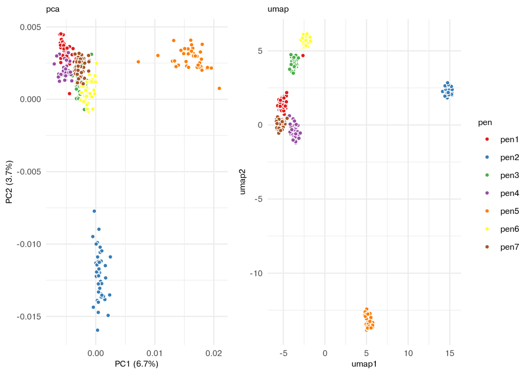

```r
legend             <- get_legend(pca_plot + ggplot2::theme(legend.box.margin = ggplot2::margin(0, 0, 0, 5)))
unsupervised_plot  <- plot_grid(pca_plot+theme(legend.position = "none"), umap_plot+theme(legend.position = "none"), ncol = 2)
(unsupervised_plot2 <- plot_grid(unsupervised_plot, legend, rel_widths = c(8,1)))
```

## Visualize unsupervised age patterns

### Umap

```r
um <- umap::umap(x)

umap_plot <-
    um$layout |>
    as_tibble() |>
    mutate(age = age) |>
    ggplot(aes(x=V1, y=V2, fill = age))+
    geom_point(color = "white", shape=21)+
    scale_fill_distiller(palette = "YlGnBu")+
    theme_minimal()+
    labs(x = "umap1", y="umap2", title = "umap")+
    theme(
      axis.text = element_text(size=8),
      axis.title = element_text(size=8),
      plot.title = element_text(size=8),
      legend.text = element_text(size=8),
      legend.title = element_text(size=8)
    )
```

### PCA

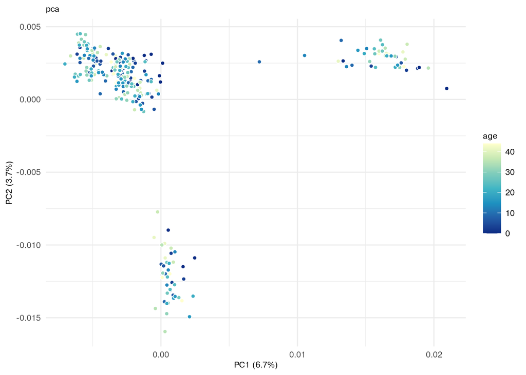

```r
pca <- prcomp(x)
variance_explained <- summary(pca)$importance[2,1:2]
variance_explained <- round(variance_explained, 3)*100
(
pca_plot <-
  pca$x |>
  as_tibble() |>
  mutate(age = age) |>
  ggplot(aes(x=PC1, y=PC2, fill = age))+
  geom_point(color = "white", shape=21)+
  scale_fill_distiller(palette = "YlGnBu")+
  labs(title = "pca", x=paste0("PC1 (", variance_explained[1], "%)"), y=paste0("PC2 (", variance_explained[2], "%)"))+
  theme_minimal()+
    theme(
      axis.text = element_text(size=8),
      axis.title = element_text(size=8),
      plot.title = element_text(size=8),
      legend.text = element_text(size=8),
      legend.title = element_text(size=8)
    )
)
```

Combined unsupervised age plot

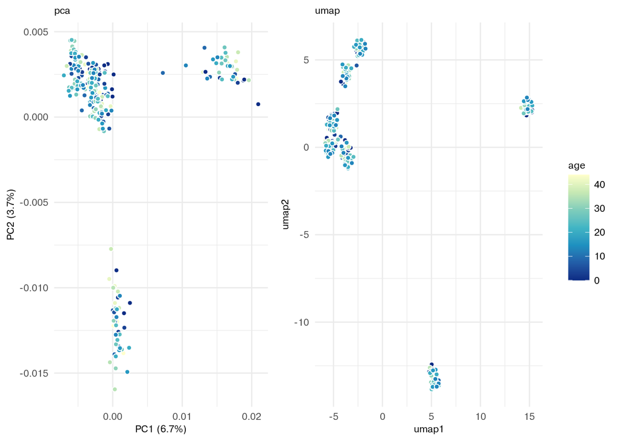

```r
legend             <- get_legend(pca_plot + ggplot2::theme(legend.box.margin = margin(0, 0, 0, 5)))
unsupervised_plot  <- plot_grid(pca_plot+theme(legend.position = "none"), umap_plot+theme(legend.position = "none"), ncol = 2)
(unsupervised_plot2 <- plot_grid(unsupervised_plot, legend, rel_widths = c(8,1)))
```

# Supervised machine learning

```r
pen       <- paste0("pen", inkdata2 |> filter(type == "sample") |> pull(pen))
age       <- inkdata2 |> filter(type == "sample") |> pull(age)
x         <- inkdata2 |> filter(type == "sample") |> select(starts_with("M"))
val_data  <- inkdata2 |> filter(type == "validation") |> select(starts_with("M"))
signature <- inkdata2 |> filter(type == "validation") |> select(-starts_with("M")) |> pull(index)
```

### Ink discrimination Model!

Obtain: - cross validated hold out class predictions (variable: preds) - cross validated hold out class probabilities (variable: preds) - for each fold predict (1 and 2) for the validation data (to average in the end) - get the cross validated feature impact on the observations. I.e., how much does feature X influence the prediction of a given sample.

```r
#, cache = TRUE}

preds                  <- list()
shap_impact_all        <- list()
signature_preds        <- list()
shap_impact_signatures <- list()

for (i in 1:length(unique(age))){

  # Hold out one triplicate at a time (i.e., all triplicates in one time point)
  timepoint <- unique(age)[i]
  test_x    <- x[age==timepoint,]
  train_x   <- x[age!=timepoint,]
  test_y    <- pen[age==timepoint]
  train_y   <- pen[age!=timepoint]

  # make cross validated model on the training data
  fit_pen <- glmnet::cv.glmnet(
    x=as.matrix(train_x),
    y=as.numeric(gsub("pen", "", train_y)),
    family = "multinomial",
    type.multinomial = "grouped",
    nfolds = 10)

  # get the important features (with beta coefficients > 0)
  feature_importance <-
    coef(fit_pen) |>
    map(as.matrix) |>
    map(as_tibble, rownames="feature") |>
    map(magrittr::set_colnames, c("feature", "value")) |>
    map(arrange, -abs(value)) |>
    map(filter, abs(value)>0)

  #
  m <- coef(fit_pen) |>
    map(as.matrix) |>
    map(as_tibble, rownames = "feature") |>
    bind_rows(.id = "pen") |> # One feature importance matrix per pen
    pivot_wider(values_from = "1", names_from = "feature") |>
    select(-pen) |>
    as.matrix()


  used_features <- feature_importance |> bind_rows() |> pull(feature) |> unique()

  # Make the test data numeric matrix
  inkdata_matrix <-
    test_x |>
    mutate("intercept" = 1) |> # The bias term for linear modeling
    select(intercept, starts_with("M")) |>
    as.matrix()

  predicted <- predict(fit_pen, as.matrix(test_x), s = "lambda.min", type = "class") |> as.numeric()


  # Get the cross validation data impact
  impact <-
    as.list(1:nrow(inkdata_matrix)) |>
    map(~as_tibble(inkdata_matrix[.x,]*m)) |> # Matrix multiplication of feature values and model coefficients
    map(select, all_of(used_features)) |>
    imap(~.x[predicted[.y],]) |>
    bind_rows(.id = "index") |>
    mutate(pred = predicted, obs = test_y, index = which(age==timepoint)) |>
    select(pred, obs, everything())

  shap_impact_all[[i]] <- impact

  # Get the signature validation data impact
  inkdata_matrix <-
    val_data |>
    mutate("intercept" = 1) |>
    select(intercept, starts_with("M")) |>
    as.matrix()

  predicted <- predict(fit_pen, as.matrix(val_data), s = "lambda.min", type = "class") |> as.numeric()
  impact <-
    as.list(1:nrow(inkdata_matrix)) |>
    map(~as_tibble(inkdata_matrix[.x,]*m)) |>
    map(select, all_of(used_features)) |>
    imap(~.x[predicted[.y],]) |>
    bind_rows(.id = "index") |>
    mutate(pred = predicted, obs = signature) |>
    select(pred, obs, everything(), -index)

  shap_impact_signatures[[i]] <- impact

  # Save signature predictions
  signature_preds[[i]] <- predict(fit_pen, as.matrix(val_data), type = "response")

  # Save cross validation predictions
  preds[[i]] <- predict(fit_pen, as.matrix(test_x), type="response") |> as_tibble() |> mutate(obs = test_y, pred = predict(fit_pen, as.matrix(test_x), type="class"))
}

# Concatenate all the feature importance data
feature_importance <- shap_impact_all |> bind_rows() |> select(starts_with("M")) |> map_dbl(var, na.rm=T) |> sort(decreasing = T)
```

### Machine learning performance

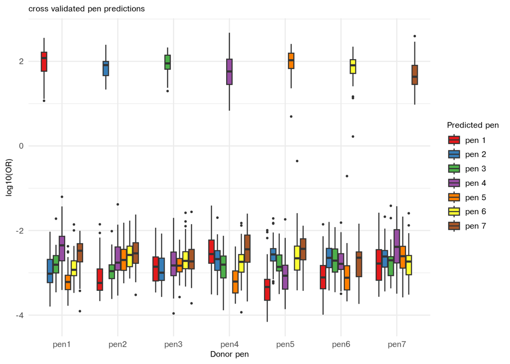

```r
(
  predictional_performance <-
    preds |>
    bind_rows() |>
    magrittr::set_colnames(c(paste0("pen", 1:7), "obs", "pred")) |>
    mutate(pred = paste0("pen ", unlist(pred))) |>
    pivot_longer(starts_with("pen")) |>
    mutate(value = log10(value/(1-value))) |>
    ggplot(aes(x=name, y=value, fill=pred)) +
    geom_boxplot(outlier.size = 0.5)+
    scale_fill_brewer(palette = "Set1")+
    scale_color_brewer(palette = "Set1")+
    guides(fill = guide_legend(title = "Predicted pen"))+
    labs(y = "log10(OR)", x = "Donor pen", title = "cross validated pen predictions")+
    theme_minimal()+
    theme(axis.text = element_text(size=8),
          axis.title = element_text(size=8),
          plot.title = element_text(size=8),
          legend.title = element_text(size=8),
          legend.text = element_text(size=8),
          legend.key.size = unit(.5, 'cm'))
)
```

### Predictions on validation data

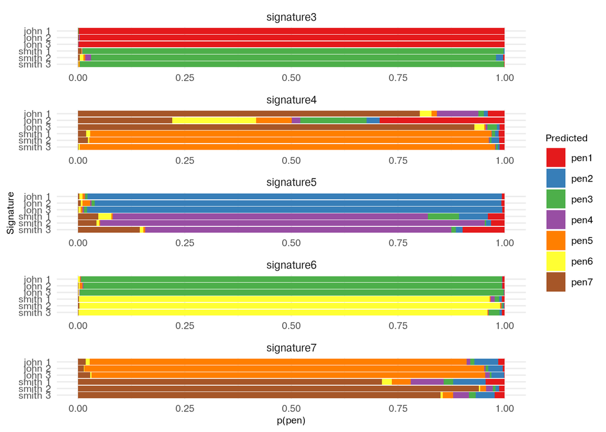

```r
signature <- inkdata2 |> filter(type == "validation") |> pull(index)
mean_prediction <-
  signature_preds |>
  map(as_tibble) |>
  map(magrittr::set_colnames, paste0("pen", 1:7)) |>
  map(mutate, "segment" = signature) |>
  map(pivot_longer, cols = starts_with("p"))  |>
  bind_rows() |>
  group_by(name, segment) |>
  summarise(value = mean(value)) |>
  pivot_wider(names_from = name, values_from = value)

(
blinded_predictions <-
  mean_prediction |>
  pivot_longer(cols = starts_with("pen")) |>
  mutate(
    signature = gsub("_.*", "", segment),
    name1 = gsub(".*_", "", segment),
    techrep = gsub("signature._|_john|_smith", "", segment),
    name_rep = factor(paste(name1, techrep), levels = rev(c("john 1", "john 2", "john 3", "smith 1", "smith 2", "smith 3")))) |>
  ggplot(aes(y=name_rep, x=value, fill=name))+
  geom_col()+
  scale_fill_brewer(palette = "Set1")+
  facet_wrap(~signature, ncol=1, scales = "free")+
  theme_minimal()+
  guides(fill = guide_legend(title = "Predicted"))+
  labs(x="p(pen)", y="Signature")+
    theme(axis.text = element_text(size=8),
          axis.title = element_text(size=8),
          plot.title = element_text(size=8),
          legend.title = element_text(size=8),
          legend.text = element_text(size=8))
)
```

### Assessment of the predictions - do they fit into the distributions of the training data?

> We are especially interested in signature 4 as it is uncertain in its “john” predictions

The values on y are the beta values of the linear model multiplied onto the intensity of their variable (feature). I.e., if we have a model with only one predictor the linear model would be: y = a*x + b. In this case the value on the y-value on the plot would be given by a multiplied by x.

```r
n = 10
validation_shap <-
  shap_impact_signatures |>
  bind_rows() |>
  select(pred, obs, all_of(names(feature_importance)[1:n])) |>
  pivot_longer(cols = starts_with("M")) |>
  group_by(obs, name) |>
  summarise(value = mean(value), pred = pred[1]) |>
  mutate(id = gsub("signature|_._", "", obs))

validation_shap |>
  group_by(pred)
```

```
## # A tibble: 300 × 5
## # Groups:   pred [7]
##    obs               name        value  pred id
##    <chr>             <chr>       <dbl> <dbl> <chr>
##  1 signature3_1_john M167.1291  0.711      1 3john
##  2 signature3_1_john M196.1372  0.0349     1 3john
##  3 signature3_1_john M238.1189 -0.507      1 3john
##  4 signature3_1_john M238.1697  0.781      1 3john
##  5 signature3_1_john M282.1888  1.07       1 3john
##  6 signature3_1_john M366.1055 -0.275      1 3john
##  7 signature3_1_john M419.257  -0.0471     1 3john
##  8 signature3_1_john M467.2245 -0.0240     1 3john
##  9 signature3_1_john M559.0993 -0.215      1 3john
## 10 signature3_1_john M603.1985 -0.290      1 3john
## # … with 290 more rows
```

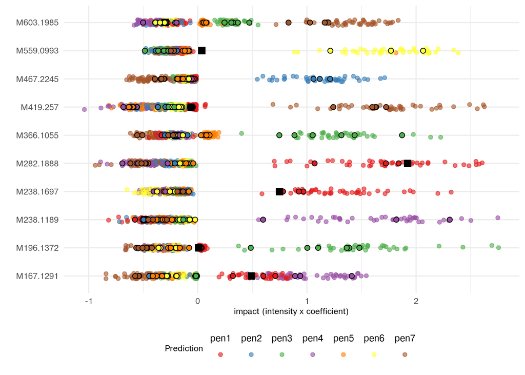

```r
true_preds <-
  validation_shap |>
  mutate(true_pred = !grepl("signature4_2_john", obs))

(model_impact <-
  shap_impact_all |>
  bind_rows() |>
  select(pred, obs, index, all_of(names(feature_importance)[1:n])) |>
  pivot_longer(cols = starts_with("M")) |>
  ggplot(aes(x=value, y=name, color = obs))+
  geom_jitter(alpha = 0.6, height =0.1)+#, position = position_jitterdodge(jitter.height = 0.1, jitter.width = 0.1))+
  geom_point(data = validation_shap,
             aes(x=value, y=name, fill = paste0("pen", pred)),
             color = "black",
             shape=ifelse(true_preds$true_pred, 21, 15),
             size =ifelse(true_preds$true_pred, 2, 3),
             show.legend = F)+#,position = position_jitterdodge(jitter.height = 0.1, jitter.width = 0.1))+
  scale_color_brewer(palette = "Set1")+
  scale_fill_brewer(palette = "Set1")+
  theme_minimal()+
  guides(color=guide_legend(
    title = "Prediction",
    legend.box = "horizontal",
    #title.position="top",
    label.position = "top",
    title.hjust = 0.5,
    nrow=1)
    )+
  labs(x=paste0("impact (intensity"," x ","coefficient)"), y = "")+
  theme(
    legend.position = "bottom",
    legend.key.width= unit(0.9, 'cm'),
    legend.title = element_text(size=8),
    axis.title = element_text(size=8),
    axis.text = element_text(size=8))
  )
```

> NOTICE: At this point we do not know if the predictions are correct.

# All pen regressions

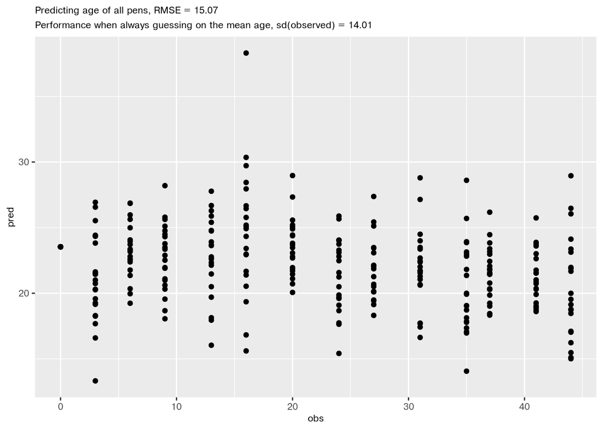

```r
pen       <- paste0("pen", inkdata2 |> filter(type == "sample") |> pull(pen))
age       <- inkdata2 |> filter(type == "sample") |> pull(age)
x         <- inkdata2 |> filter(type == "sample") |> select(starts_with("M"))
val_data  <- inkdata2 |> filter(type == "validation") |> select(starts_with("M"))
signature <- inkdata2 |> filter(type == "validation") |> select(-starts_with("M")) |> pull(index)
preds2 <- list()
for (i in 1:length(unique(age))){
    a <- unique(age)[i]
    test_x <- x[age==a,]
    test_y <- age[age==a]
    train_x <- x[age!=a,]
    train_y <- age[age!=a]

    fit_age2 <-
      glmnet::cv.glmnet(
      x=as.matrix(train_x),
      y=train_y,
      nfolds = 10)

    predicted <- predict(fit_age2, as.matrix(test_x), s = "lambda.min") |> as.numeric()
    preds2[[i]] <-
      predict(fit_age2, as.matrix(test_x)) |>
      as_tibble() |> mutate(obs = test_y)
  }

preds2 <-
  preds2 |>
  bind_rows() |>
  magrittr::set_colnames(c("pred", "obs")) |>
  mutate(RMSE = sqrt(mean((pred-obs)^2)))

(
  all_pen_regression <-
    preds2 |>
    ggplot(aes(x=obs, y=pred))+
    geom_point()+
    labs(title = paste0("Predicting age of all pens, RMSE = ", round(preds2$RMSE[1], 2)),
        subtitle = paste0("Performance when always guessing on the mean age, sd(observed) = ", round(sd(preds2$obs), 2)))+
    theme(
      axis.text = element_text(size=8),
      axis.title = element_text(size=8),
      plot.title = element_text(size=8),
      plot.subtitle = element_text(size=8)
    )
)
```

### Model age!

```r
penwise_age <- list()
for (pen_id in unique(pen)){

  age_holdout_fits       <- list()
  preds                  <- list()
  shap_impact_all        <- list()
  signature_preds        <- list()
  shap_impact_signatures <- list()

  for (i in 1:length(unique(age))){
    a       <- unique(age)[i]
    test_x  <- x[age==a&pen_id==pen,]
    train_x <- x[age!=a&pen_id==pen,]
    test_y  <- age[age==a&pen_id==pen]
    train_y <- age[age!=a&pen_id==pen]

    fit_age2 <-
      glmnet::cv.glmnet(
      x=as.matrix(train_x),
      y=train_y,
      nfolds = 10)

    feature_importance <-
      coef(fit_age2) |>
      as.matrix() |>
      as_tibble(rownames="feature") |>
      magrittr::set_colnames(c("feature", "value")) |>
      arrange(-abs(value)) |>
      filter(abs(value)>0)

    m <- coef(fit_age2) |>
      as.matrix() |>
      as_tibble(rownames = "feature") |>
      mutate(s1 = as.numeric(s1)) |>
      pivot_wider(names_from = feature, values_from=s1) |>
      as.matrix()

    used_features <- feature_importance |> bind_rows() |> pull(feature) |> unique()

    inkdata_matrix <-
      test_x |>
      mutate("intercept" = 1) |>
      select(intercept, starts_with("M")) |>
      as.matrix()

    predicted <- predict(fit_age2, as.matrix(test_x), s = "lambda.min") |> as.numeric()

    impact <-
      as.list(1:nrow(inkdata_matrix)) |>
      map(~as_tibble(inkdata_matrix[.x,]*m)) |>
      map(select, all_of(used_features)) |>
      bind_rows(.id = "index") |>
      mutate(pred = predicted, obs = test_y, index = which(age==a&pen_id==pen)) |>
      select(pred, obs, everything())

    shap_impact_all[[i]] <- impact

    inkdata_matrix <-
      val_data |>
      mutate("intercept" = 1) |>
      select(intercept, starts_with("M")) |>
      as.matrix()

    age_holdout_fits[[i]] <- fit_age2
    preds[[i]] <-
      predict(fit_age2, as.matrix(test_x)) |>
      as_tibble() |> mutate(obs = test_y, pred = predict(fit_age2, as.matrix(test_x), type="class"))
  }

  feature_importance <- shap_impact_all |> bind_rows() |> select(starts_with("M")) |> map_dbl(var, na.rm=T) |> sort(decreasing = T)

  penwise_age[[pen_id]] <-
    list("feature_importance"=feature_importance,
         "predictions"=preds,
         "hold_out_fits"=age_holdout_fits
         )

}
```

```r
get_regression_preds <- function(x) {
  x[["predictions"]] |>
    bind_rows() |>
    select(pred = lambda.1se, obs)
}

penwise_age |>
  map(get_regression_preds) |>
  bind_rows(.id="pen") |>
  group_by(pen) |>
  summarise(RMSE = sqrt(mean((pred-obs)^2)),
            sd   = sd(obs))
```

```
## # A tibble: 7 × 3
##   pen    RMSE    sd
##   <chr> <dbl> <dbl>
## 1 pen1   14.4  14.2
## 2 pen2   13.7  14.2
## 3 pen3   15.0  14.2
## 4 pen4   12.9  14.2
## 5 pen5   14.8  14.2
## 6 pen6   14.7  14.2
## 7 pen7   15.1  14.2
```

```r
p_values <-
  x |>
  mutate(age = age, pen = pen) |>
  pivot_longer(cols = -c(age, pen)) |>
  group_by(pen, name) |>
  summarise(
    correlation = cor(x=value, y=age, method = "spearman"),
    p.value = cor.test(value, age, method = "spearman")$p.value,
    fdr = p.adjust(p.value)
  )

fdr_count <-
  p_values |>
  group_by(pen) |>
  count("significant" = fdr<0.01) |>
  filter(significant) |>
  arrange(-n)

ml_performance_RMSE <- penwise_age |>
  map(get_regression_preds) |>
  bind_rows(.id="pen") |>
  group_by(pen) |>
  summarise(RMSE = sqrt(mean((pred-obs)^2)),
            sd   = sd(obs))

fdr_count |> ungroup() |>
  left_join(ml_performance_RMSE) |>
  select(pen, fdr = n, RMSE)
```

```
## # A tibble: 7 × 3
##   pen     fdr  RMSE
##   <chr> <int> <dbl>
## 1 pen1    122  14.4
## 2 pen4    117  12.9
## 3 pen5     68  14.8
## 4 pen2     66  13.7
## 5 pen3     64  15.0
## 6 pen6     51  14.7
## 7 pen7     44  15.1
```

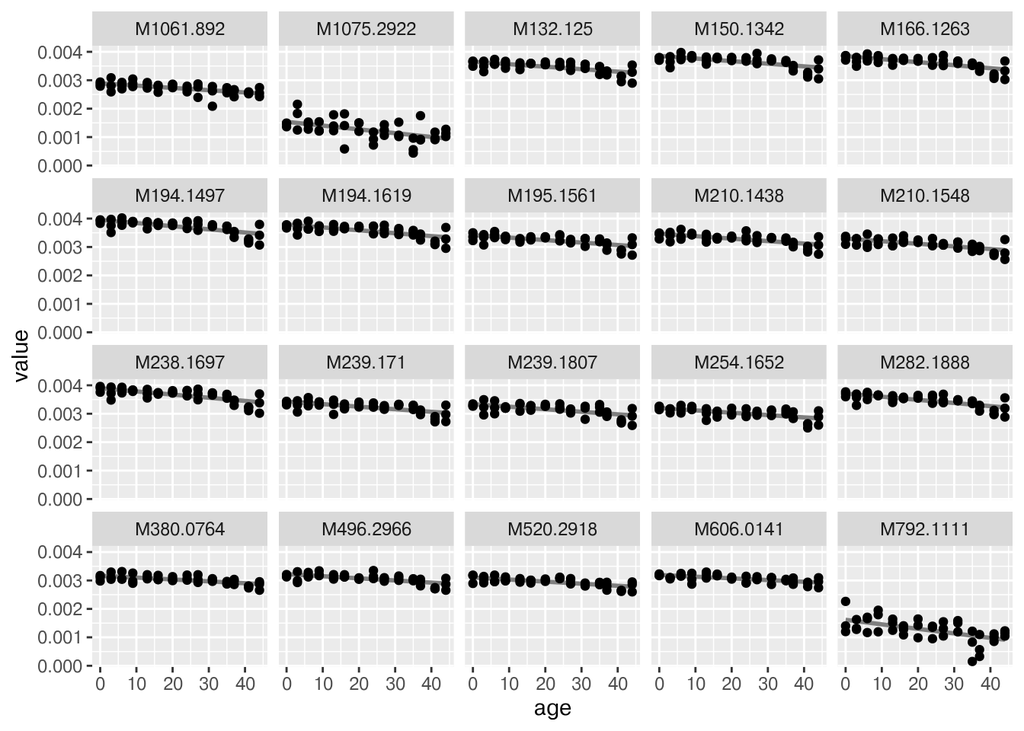

```r
features <-
  p_values |>
  filter(pen=="pen1") |>
  slice_min(fdr, n=20)

x |>
  mutate(age=age, pen=pen) |>
  filter(pen == "pen1") |>
  select(age, all_of(features$name)) |>
  pivot_longer(cols = -age) |>
  ggplot(aes(x=age, y=value))+
  geom_smooth(method = "lm", se = F, color  = "gray50")+
  geom_point()+
  facet_wrap(~name)
```

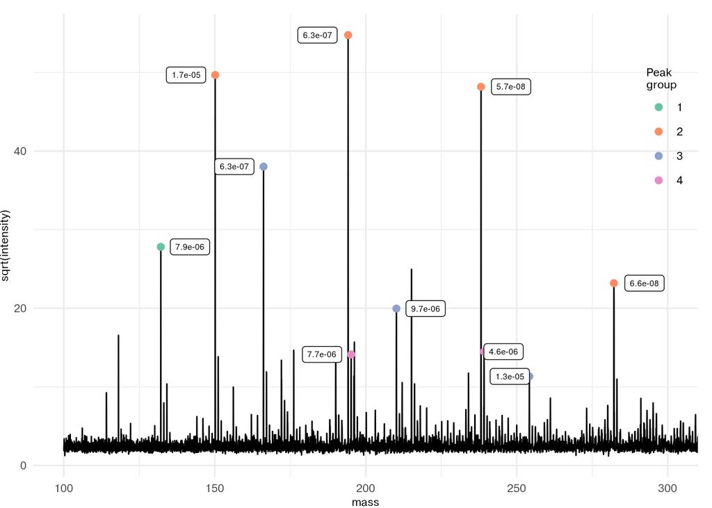

```r
important_peaks <-
  tibble(mass_preprocessed = as.numeric(gsub("M", "", features$name)), important = TRUE,
         fdr  = features$fdr)

# Map preprocessed data to raw data
indeces <- sapply(important_peaks$mass_preprocessed, function(x) which.min(abs(df2[df2$pen == 1,]$mass - x)))
important_peaks$intensity = df2[df2$pen == 1,]$intensity[indeces]
important_peaks$mass = df2[df2$pen == 1,]$mass[indeces]


# Automatic polymer detection

assignments <- list("indexed" = c(), "id" = c())
min_mass <- 100
max_mass <- 300
important_peaks <- important_peaks |> filter(mass > min_mass & mass < max_mass) |> arrange(mass)

index = 1
for (index in 1:nrow(important_peaks)){

  if (important_peaks$mass[index] %in% assignments$id){next}
  new_id   <- ifelse(is.null(assignments$indexed[length(assignments$indexed)]), 1, assignments$indexed[length(assignments$indexed)]+1)
  sequence <- seq(important_peaks$mass[index], max_mass, 44.05)
  matches  <- which(round(important_peaks$mass) %in% round(sequence))
  assignments$indexed <- c(assignments$indexed, rep(new_id, length(matches)))
  assignments$id      <- c(assignments$id, important_peaks$mass[matches])
}


# Remove double hits
important_peaks <-
  assignments |>
  as_tibble() |>
  mutate(mass = id, id = round(id)) |>
  filter(!duplicated(assignments$id)) |>
  left_join(important_peaks) |>
  filter(!duplicated(.data$id))


(
raw_data_significant_peaks <-
  df2 |>
  filter(pen == 1) |>
  ggplot(aes(x=mass, y=sqrt(intensity)))+
  geom_line()+
  geom_point(data=important_peaks, size = 2, aes(x=mass, y=sqrt(intensity), color = factor(indexed)))+
  geom_label_repel(data=important_peaks[important_peaks$mass<max_mass & important_peaks$mass>min_mass,],
                   aes(label = signif(fdr, 2), x=mass, y=sqrt(intensity)),
                   segment.color = 'grey50',
                   size=2,
                   direction = "x",
                   force = 20)+
  theme_minimal()+
  coord_cartesian(xlim = c(min_mass, max_mass))+
  scale_color_brewer(palette = "Set2")+
  guides(color=guide_legend(title = "Peak\ngroup"))+
  theme(legend.position = c(0.95, 0.75), plot.margin = margin(10,10,0,0),
      axis.text = element_text(size=8),
      axis.title = element_text(size=8),
      plot.title = element_text(size=8),
      legend.text = element_text(size=8),
      legend.title = element_text(size=8))
)
```

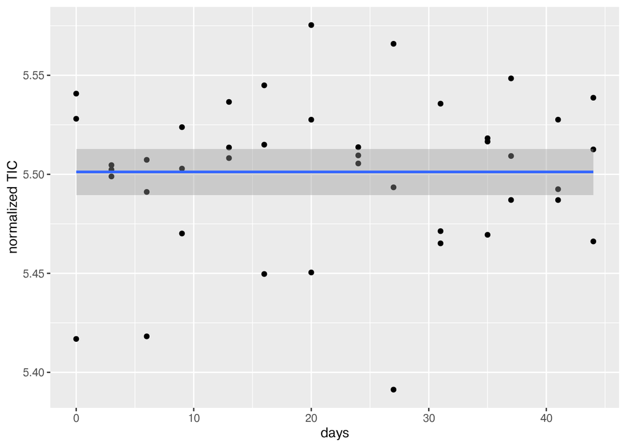

```r
(figureS3_aging_sanity_check <- x[pen == "pen1",] |>
  rowSums() |>
  as_tibble() |>
  mutate(age = age[pen == "pen1"]) |>
  ggplot(aes(x=age, y=value))+geom_point()+geom_smooth(method = "gam")+
  labs(x = "days", y="normalized TIC")
)
```

#### The pen with the most correlated features is pen1. Let’s do a PCA

```r
pen1 <-
  x |>
  mutate(age=age, pen=pen) |>
  filter(pen == "pen1")

ms            <- list()
ms$values     <- pen1 |> select(-age) |> select(-pen)
ms$rowinfo    <- pen1 |> select(days = age, pen) |> rowid_to_column()
pca_plot_pen1 <- plot_pca(ms, color_label="days", palette = "YlGnBu", tech_rep = "days")
```

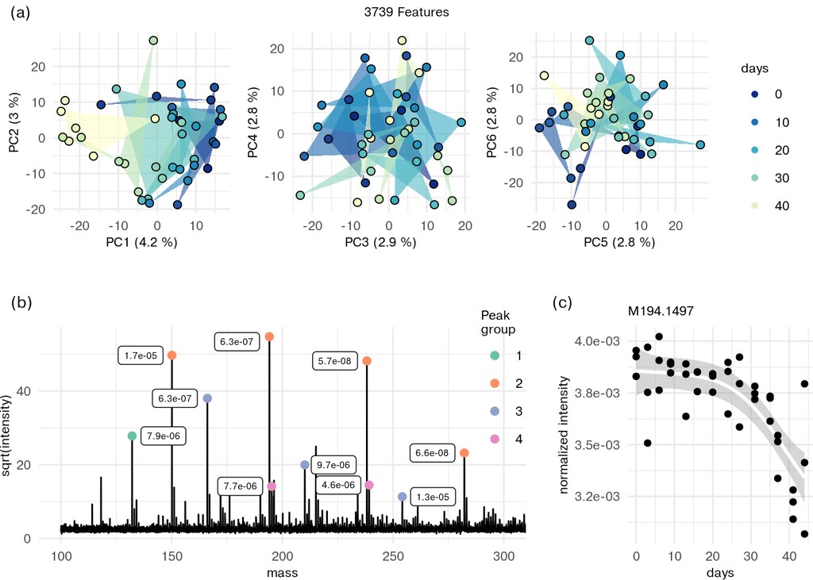

```r
dense_data <- x[pen == "pen1", "M194.1497"]
dense_data$age <- age[pen == "pen1"]

summed_significant_peaks <-
  dense_data |>
  ggplot(aes(x=age, y=M194.1497))+
  geom_smooth(color = "white", method = "gam")+
  geom_point()+
  labs(x="days", y="normalized intensity", title = "M194.1497")+
  theme_minimal()+
  theme(plot.margin = margin(10,0,0,10),
      axis.text = element_text(size=8),
      axis.title = element_text(size=8),
      plot.title = element_text(size=8),
      legend.text = element_text(size=8),
      legend.title = element_text(size=8))+
  scale_y_continuous(labels = function(n) scales::scientific(x = n, digits = 2))

polymer_plot <-
  plot_grid(raw_data_significant_peaks, summed_significant_peaks, rel_widths = c(4, 2), align = "h", labels = c("(b)", "(c)"), label_fontface = "plain", label_size = 10)

plot_grid(pca_plot_pen1+theme(plot.margin = margin(0,0,20,0)), polymer_plot, ncol = 1, labels = c("(a)", ""), label_fontface = "plain", label_size = 10)
```

###### Well.. lets do it for all pens

[figure not shown]

```r
pen_plots <- list()

for (pen_id in unique(pen)){

  pen1 <-
    x |>
    mutate(age=age, pen=pen) |>
    filter(pen == pen_id)

  ms <- list()
  ms$values <- pen1 |> select(-age) |> select(-pen)
  ms$rowinfo <- pen1 |> select(days = age, pen) |> rowid_to_column()
  pca_plot_pen1 <- plot_pca(ms, color_label="days", palette = "YlGnBu", tech_rep = "days")

  pen_plots[[pen_id]] <- pca_plot_pen1

}

(all_pca_plots <- cowplot::plot_grid(plotlist = pen_plots, labels = names(pen_plots), label_size = 8, label_fontface = "plain", ncol = 1))
```